# MuscleHub A/B Test And Analysis

## Introduction

MuscleHub is a fancy gym, Managed by Ms. Janet. She thinks the fitness test visitors took as a step to buy a membership test intimidates prospective visitors and so she has set up an A/B test. Visitors who are considering buying a membership at MuscleHub have to follow the following steps.

1. Take a fitness test with a personal trainer
2. Fill out an application for the gym
3. Send in their payments for their first month’s membership

Based on Janet’s set up visitors will randomly be assigned to one of two groups

1. Group A will be asked to take a fitness test with a personal trainer.
2. Group B will be asked to skip the first step and fill out the application. Janet’s hypothesis is that visitors assigned to group b will be more likely to purchase a membership to MuscleHub. This analysis, using visitors data, interviews conducted during the visits and conducting an A/B test, will try to find out the significance of skipping the first step, which is taking a fitness test.

## Data Overview

MuscleHub gym manager, Janet has SQLite database. The data will be used by downloading it to a CSV file. A codecademy library which allows us to use SQL queries directly on a Jupyter notebook is used to analyze our data. The data contains information about potential gym customers who have visited MuscleHub, customers in "Group A", who were given a fitness test, customers (both "Group A" and "Group B") who filled out an application and those who purchased a membership to MuscleHub.

```python
#some of the datas we have are the following
from codecademySQL import sql_query
```

```python
#visits
sql_query('''
SELECT *
FROM visits
LIMIT 5
''')
```

|  | index | first_name | last_name | email | gender | visit_date |
| --- | --- | --- | --- | --- | --- | --- |
| 0 | 0 | Karen | Manning | Karen.Manning@gmail.com | female | 5-1-17 |
| 1 | 1 | Annette | Boone | AB9982@gmail.com | female | 5-1-17 |
| 2 | 2 | Salvador | Merritt | SalvadorMerritt12@outlook.com | male | 5-1-17 |
| 3 | 3 | Martha | Maxwell | Martha.Maxwell@gmail.com | female | 5-1-17 |
| 4 | 4 | Andre | Mayer | AndreMayer90@gmail.com | male | 5-1-17 |

```python
#applications
sql_query('''
SELECT *
FROM applications
LIMIT 5
''')
```

|  | index | first_name | last_name | email | gender | application_date |
| --- | --- | --- | --- | --- | --- | --- |
| 0 | 0 | Roy | Abbott | RoyAbbott32@gmail.com | male | 2017-08-12 |
| 1 | 1 | Agnes | Acevedo | AgnesAcevedo1@gmail.com | female | 2017-09-29 |
| 2 | 2 | Roberta | Acevedo | RA8063@gmail.com | female | 2017-09-15 |
| 3 | 3 | Darren | Acosta | DAcosta1996@hotmail.com | male | 2017-07-26 |
| 4 | 4 | Vernon | Acosta | VAcosta1975@gmail.com | male | 2017-07-14 |

```python
#fitness_tests
sql_query('''
select *
from fitness_tests
limit 5
''')
```

|  | index | first_name | last_name | email | gender | fitness_test_date |
| --- | --- | --- | --- | --- | --- | --- |
| 0 | 0 | Kim | Walter | KimWalter58@gmail.com | female | 2017-07-03 |
| 1 | 1 | Tom | Webster | TW3857@gmail.com | male | 2017-07-02 |
| 2 | 2 | Marcus | Bauer | Marcus.Bauer@gmail.com | male | 2017-07-01 |
| 3 | 3 | Roberta | Best | RB6305@hotmail.com | female | 2017-07-02 |
| 4 | 4 | Carrie | Francis | CF1896@hotmail.com | female | 2017-07-05 |

```python
#applications
sql_query('''
select *
from applications
limit 5
''')
```

|  | index | first_name | last_name | email | gender | application_date |
| --- | --- | --- | --- | --- | --- | --- |
| 0 | 0 | Roy | Abbott | RoyAbbott32@gmail.com | male | 2017-08-12 |
| 1 | 1 | Agnes | Acevedo | AgnesAcevedo1@gmail.com | female | 2017-09-29 |
| 2 | 2 | Roberta | Acevedo | RA8063@gmail.com | female | 2017-09-15 |
| 3 | 3 | Darren | Acosta | DAcosta1996@hotmail.com | male | 2017-07-26 |
| 4 | 4 | Vernon | Acosta | VAcosta1975@gmail.com | male | 2017-07-14 |

```python
#purchases
sql_query('''
select *
from purchases
limit 5
''')
```

|  | index | first_name | last_name | email | gender | purchase_date |
| --- | --- | --- | --- | --- | --- | --- |
| 0 | 0 | Roy | Abbott | RoyAbbott32@gmail.com | male | 2017-08-18 |
| 1 | 1 | Roberta | Acevedo | RA8063@gmail.com | female | 2017-09-16 |
| 2 | 2 | Vernon | Acosta | VAcosta1975@gmail.com | male | 2017-07-20 |
| 3 | 3 | Darren | Acosta | DAcosta1996@hotmail.com | male | 2017-07-27 |
| 4 | 4 | Dawn | Adkins | Dawn.Adkins@gmail.com | female | 2017-08-24 |

Data only important for this purpose pooled out using SQL queries and merge in one big data frame called df. The following query select datas that we need.

```python
df = sql_query('''
SELECT visits.first_name,
       visits.last_name,
       visits.visit_date,
       fitness_tests.fitness_test_date,
       applications.application_date,
       purchases.purchase_date
FROM visits
LEFT JOIN fitness_tests
    ON fitness_tests.first_name = visits.first_name
    AND fitness_tests.last_name = visits.last_name
    AND fitness_tests.email = visits.email
LEFT JOIN applications
    ON applications.first_name = visits.first_name
    AND applications.last_name = visits.last_name
    AND applications.email = visits.email
LEFT JOIN purchases
    ON purchases.first_name = visits.first_name
    AND purchases.last_name = visits.last_name
    AND purchases.email = visits.email
WHERE visits.visit_date >= '7-1-17'
''')
df
```

|  | first_name | last_name | visit_date | fitness_test_date | application_date | purchase_date |
| --- | --- | --- | --- | --- | --- | --- |
| 0 | Kim | Walter | 7-1-17 | 2017-07-03 | None | None |
| 1 | Tom | Webster | 7-1-17 | 2017-07-02 | None | None |
| 2 | Edward | Bowen | 7-1-17 | None | 2017-07-04 | 2017-07-04 |
| 3 | Marcus | Bauer | 7-1-17 | 2017-07-01 | 2017-07-03 | 2017-07-05 |
| 4 | Roberta | Best | 7-1-17 | 2017-07-02 | None | None |
| 5 | Joseph | Foley | 7-1-17 | None | None | None |
| 6 | Carrie | Francis | 7-1-17 | 2017-07-05 | None | None |
| 7 | Sharon | William | 7-1-17 | None | None | None |
| 8 | Teresa | Yates | 7-1-17 | 2017-07-02 | None | None |
| 9 | Salvador | Cardenas | 7-1-17 | 2017-07-07 | 2017-07-06 | None |
| 10 | Glen | Barker | 7-1-17 | None | None | None |
| 11 | Valerie | Munoz | 7-1-17 | 2017-07-03 | 2017-07-05 | 2017-07-06 |
| 12 | Jeremy | Howe | 7-1-17 | 2017-07-06 | None | None |
| 13 | Joel | Combs | 7-1-17 | 2017-07-01 | None | None |
| 14 | Oscar | Forbes | 7-1-17 | None | None | None |
| 15 | Darryl | Albert | 7-1-17 | None | None | None |
| 16 | Armando | Valenzuela | 7-1-17 | None | None | None |
| 17 | June | Ayers | 7-1-17 | None | None | None |
| 18 | Nancy | Morin | 7-1-17 | 2017-07-05 | None | None |
| 19 | Lorraine | Lindsay | 7-1-17 | 2017-07-05 | None | None |
| 20 | Carla | Guerrero | 7-1-17 | 2017-07-03 | None | None |
| 21 | Gina | Monroe | 7-1-17 | None | None | None |
| 22 | Andy | Roberson | 7-1-17 | 2017-07-05 | None | None |
| 23 | Arnold | Madden | 7-1-17 | 2017-07-01 | None | None |
| 24 | Norman | Frederick | 7-1-17 | None | None | None |
| 25 | Morris | Lott | 7-1-17 | 2017-07-03 | None | None |
| 26 | Cory | Gamble | 7-1-17 | None | None | None |
| 27 | Marcus | Gilliam | 7-1-17 | None | None | None |
| 28 | Clifford | Guthrie | 7-1-17 | 2017-07-04 | None | None |
| 29 | Terry | Merrill | 7-1-17 | None | None | None |
| ... | ... | ... | ... | ... | ... | ... |
| 4974 | Dolores | Nielsen | 9-9-17 | 2017-09-14 | None | None |
| 4975 | Kathy | Drake | 9-9-17 | None | None | None |
| 4976 | Misty | Roberson | 9-9-17 | 2017-09-14 | None | None |
| 4977 | Marian | Daniel | 9-9-17 | None | None | None |
| 4978 | Wanda | Snow | 9-9-17 | None | None | None |
| 4979 | Nathan | Gallegos | 9-9-17 | None | None | None |
| 4980 | Evelyn | Reeves | 9-9-17 | None | None | None |
| 4981 | Kelly | Tate | 9-9-17 | 2017-09-12 | None | None |
| 4982 | Willie | Mann | 9-9-17 | 2017-09-11 | None | None |
| 4983 | Ellen | Blake | 9-9-17 | 2017-09-10 | None | None |
| 4984 | Marjorie | Wong | 9-9-17 | None | None | None |
| 4985 | Margie | Walton | 9-9-17 | None | None | None |
| 4986 | Peter | Figueroa | 9-9-17 | 2017-09-15 | None | None |
| 4987 | Clifton | Leon | 9-9-17 | 2017-09-12 | None | None |
| 4988 | Gordon | Espinoza | 9-9-17 | 2017-09-12 | None | None |
| 4989 | Luis | Horne | 9-9-17 | None | None | None |
| 4990 | Francis | Durham | 9-9-17 | None | None | None |
| 4991 | Suzanne | Humphrey | 9-9-17 | 2017-09-09 | 2017-09-13 | 2017-09-18 |
| 4992 | Glenn | Kinney | 9-9-17 | None | None | None |
| 4993 | Jose | Stevenson | 9-9-17 | None | None | None |
| 4994 | Gregory | Wong | 9-9-17 | 2017-09-09 | None | None |
| 4995 | Dean | Mejia | 9-9-17 | 2017-09-13 | None | None |
| 4996 | Sharon | Hahn | 9-9-17 | None | None | None |
| 4997 | Adam | Grimes | 9-9-17 | None | None | None |
| 4998 | Sara | Malone | 9-9-17 | 2017-09-13 | None | None |
| 4999 | Rachel | Hensley | 9-9-17 | None | None | None |
| 5000 | Leon | Harmon | 9-9-17 | 2017-09-15 | None | None |
| 5001 | Andy | Pratt | 9-9-17 | 2017-09-15 | None | None |
| 5002 | Ruben | Nielsen | 9-9-17 | None | 2017-09-13 | None |
| 5003 | Charles | Carver | 9-9-17 | 2017-09-12 | None | None |

5004 rows × 6 columns

Janet split visitors into two groups group A and B. After grouping the visitors into two groups, knowing how many of them make it to Step2 (filling out an application) will be helpful. To calculate the percent of people in each group who complete an application, first, we need to count how many people from group A and group B either fill or not fill an application.

to start our analysis we need more modules like pandas and pyplot, lets import them first.

- `import pandas as pd`
- `from matplotlib import pyplot as plt`

```python
import pandas as pd
from matplotlib import pyplot as plt
```

We're going to add some columns to `df` to help us with our analysis.

Start by adding a column called `ab_test_group`. It should be `A` if `fitness_test_date` is not `None`, and `B` if `fitness_test_date` is `None`.

```python
#adding a column to our data frame
df['ab_test_group'] = df.fitness_test_date.apply(lambda x: 'A' if pd.notnull(x) else 'B')
```

Let's do a quick sanity check that Janet split her visitors such that about half are in A and half are in B.

Start by using `groupby` to count how many users are in each `ab_test_group`. Save the results to `ab_counts`.

```python
ab_counts =  df.groupby('ab_test_group').first_name.count().reset_index()
ab_counts
```

|  | ab_test_group | first_name |
| --- | --- | --- |
| 0 | A | 2504 |
| 1 | B | 2500 |

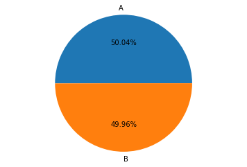

```python
#  the following pie chart shows the percentage of each group.
plt.pie(ab_counts.first_name.values, labels=['A', 'B'], autopct='%0.2f%%')
plt.axis('equal')
plt.show()
plt.savefig('ab_test_pie_chart.png')
```

## Who picks up an application?

Let's examine how many people make it to Step 2, filling out an application.

we need to add a new column in `df` called `is_application` which is `Application` if `application_date` is not `None` and `No Application`, otherwise.

```python
#adding a new column to our data frame
df['is_application'] = df.application_date.apply(lambda x: 'Application' if pd.notnull(x) else 'No Application')
```

```python
#adding another column to show how many people from each group either do or don't pick up an application.
app_counts = df.groupby(['ab_test_group', 'is_application']).first_name.count().reset_index()
```

```python
#calculating the percent of people in each group who complete an application by pivoting our app counts
app_pivot = app_counts.pivot(columns='is_application', index='ab_test_group', values='first_name').reset_index()
app_pivot
```

| is_application | ab_test_group | Application | No Application |
| --- | --- | --- | --- |
| 0 | A | 250 | 2254 |
| 1 | B | 325 | 2175 |

```python
#adding anew column for calculating the total sum of application and no application
app_pivot['Total'] = app_pivot['Application'] + app_pivot['No Application']
app_pivot
```

| is_application | ab_test_group | Application | No Application | Total |
| --- | --- | --- | --- | --- |
| 0 | A | 250 | 2254 | 2504 |
| 1 | B | 325 | 2175 | 2500 |

Calculate another column called `Percent with Application`, which is equal to `Application` divided by `Total`.

```python
#adding a new column to calculate application in percent
app_pivot['Percent with Application'] = app_pivot['Application'] / app_pivot['Total']

app_pivot
```

| is_application | ab_test_group | Application | No Application | Total | Percent with Application |
| --- | --- | --- | --- | --- | --- |
| 0 | A | 250 | 2254 | 2504 | 0.09984 |
| 1 | B | 325 | 2175 | 2500 | 0.13000 |

```python
from scipy.stats import chi2_contingency
#checking if the difference is statstically significant
contingency = [[250, 2254], [325, 2175]]
chi2_contingency(contingency)
```

```
(10.893961295282612,
 0.0009647827600722304,
 1,
 array([[ 287.72981615, 2216.27018385],
        [ 287.27018385, 2212.72981615]]))
```

The result show a p value less than 0.05 and this imply there is a significant difference in taking or not taking the fitness test.

## Who purchases a membership?

```python
#adding a new column to store how many of those who picked up an application purchased a membership
df['is_member'] = df.purchase_date.apply(lambda x: 'Member' if pd.notnull(x) else 'Not Member')
```

Now, let's create a DataFrame called `just_apps` the contains only people who picked up an application. And let's do a `groupby` to find out how many people in `just_apps` are and aren't members from each group. and by pivot just_apps.

```python
# creating a data frame
just_apps = df[df.is_application == 'Application']
```

```python
#grouping members and not members in just_apps
just_apps_counts = just_apps.groupby(['ab_test_group', 'is_member']).first_name.count().reset_index()
member_pivot = just_apps_counts.pivot(columns='is_member', index='ab_test_group', values='first_name').reset_index()
member_pivot['Total'] = member_pivot['Member'] + member_pivot['Not Member']
member_pivot['Percent Purchase'] = member_pivot['Member'] / member_pivot['Total']
member_pivot
```

| is_member | ab_test_group | Member | Not Member | Total | Percent Purchase |
| --- | --- | --- | --- | --- | --- |
| 0 | A | 200 | 50 | 250 | 0.800000 |
| 1 | B | 250 | 75 | 325 | 0.769231 |

It looks like people who took the fitness test were more likely to purchase a membership **if** they picked up an application. Why might that be?

lets do our test again.

```python
occurrence = [[200, 50], [250, 75]]
chi2_contingency(occurrence)
```

```
(0.615869230769231,
 0.43258646051083327,
 1,
 array([[195.65217391,  54.34782609],
        [254.34782609,  70.65217391]]))
```

Previously, we looked at what percent of people **who picked up applications** purchased memberships. What we really care about is what percentage of **all visitors** purchased memberships. Return to `df` and do a `groupby` to find out how many people in `df` are and aren't members from each group. we will follow the same step like before to check the significance of the diffrence.

```python
# creating a new data frame to calculate a total purchase from the total visits
purchase_counts = df.groupby(['ab_test_group', 'is_member']).first_name.count().reset_index()
final_member_pivot = purchase_counts.pivot(columns='is_member', index='ab_test_group', values='first_name').reset_index()
final_member_pivot['Total'] = final_member_pivot['Member'] + final_member_pivot['Not Member']
final_member_pivot['Percent_purchase'] = final_member_pivot['Member'] / final_member_pivot['Total']
final_member_pivot
```

| is_member | ab_test_group | Member | Not Member | Total | Percent_purchase |
| --- | --- | --- | --- | --- | --- |
| 0 | A | 200 | 2304 | 2504 | 0.079872 |
| 1 | B | 250 | 2250 | 2500 | 0.100000 |

Previously, when we only considered people who had **already picked up an application**, we saw that there was no significant difference in membership between Group A and Group B.

Now, when we consider all people who **visit MuscleHub**, we see that there might be a significant different in memberships between Group A and Group B. Perform a significance test and check.

```python
occurrence2 = [[200, 2304], [250, 2250]]
chi2_contingency(occurrence2)
```

```
(5.949182292591156,
 0.014724114645783203,
 1,
 array([[ 225.17985612, 2278.82014388],
        [ 224.82014388, 2275.17985612]]))
```

Our test result show a pvalue which is less than 0.05. This shows the statstical diference we have between this two groups.

## Summary of Our Data

In addition to this analysis, an interview was conducted with MuscleHub visitors and 75 % of them find the fitness test helpful but a bit intense. 25% doesn’t like it at all. We'd like to make a bar chart for Janet that shows the difference between Group A (people who were given the fitness test) and Group B (people who were not given the fitness test) at each state of the process:

- Percent of visitors who apply
- Percent of applicants who purchase a membership
- Percent of visitors who purchase a membership

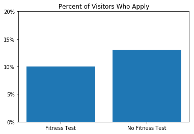

```python
#percent of visitors who apply
ax = plt.subplot()
plt.bar(range(len(app_pivot)),
       app_pivot['Percent with Application'].values)
ax.set_xticks(range(len(app_pivot)))
ax.set_xticklabels(['Fitness Test', 'No Fitness Test'])
ax.set_yticks([0, 0.05, 0.10, 0.15, 0.20])
ax.set_yticklabels(['0%', '5%', '10%', '15%', '20%'])
plt.title('Percent of Visitors Who Apply')
plt.show()
```

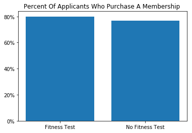

```python
#Percent of applicants who purchase a membership
ax = plt.subplot()
plt.bar(range(len(member_pivot)),
       member_pivot['Percent Purchase'].values)
ax.set_xticks(range(len(member_pivot)))
ax.set_xticklabels(['Fitness Test', 'No Fitness Test'])
ax.set_yticks([0, 0.20, 0.40, 0.60, 0.80])
ax.set_yticklabels(['0%', '20%', '40%', '60%', '80%'])
plt.title('Percent Of Applicants Who Purchase A Membership ')
plt.show()
```

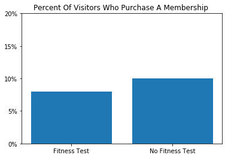

```python
#Percent of visitors who purchase a membership
ax = plt.subplot()
plt.bar(range(len(final_member_pivot)),
       final_member_pivot['Percent_purchase'].values)
ax.set_xticks(range(len(final_member_pivot)))
ax.set_xticklabels(['Fitness Test', 'No Fitness Test'])
ax.set_yticks([0, 0.05, 0.10, 0.15, 0.20])
ax.set_yticklabels(['0%', '5%', '10%', '15%', '20%'])
plt.title('Percent Of Visitors Who Purchase A Membership ')
plt.show()
```

## Recommendation

Even though the difference between applicants who purchase a membership is not significant. Based on the results we found out there is a significant difference between the two groups when we compare the total visitors who purchase a membership. The analysis shows that people in Group B are more likely to buy a membership than people in Group A. Janet hypothesis was right about the fitness test intimidates some prospective members. So, MuscleHub gym should stop giving the fitness test for visitors who want to apply for a membership.